# Factors or so-called grouping variables

2019-05-09

## Factors

```r
library("tidyverse")
library("forcats")
```

[figure not shown]

## Introduction

- In R, factors are used to work with categorical variables
- Variables that have a fixed and known set of possible values.
- They are also useful when you want to display character vectors in a non-alphabetical order.

## A short example

```r
names
```

```
## # A tibble: 6 x 2
##   surname   hobby
##   <chr>     <chr>
## 1 Marc      Climbing
## 2 Pascal    Climbing
## 3 Stefan    Swimming
## 4 Ronald    Running
## 5 Arie-Jaak Karate
## 6 Mieke     Swimming
```

```r
names$hobby <- as_factor(names$hobby)
```

## Checking the change to factor

```r
names
```

```
## # A tibble: 6 x 2
##   surname   hobby
##   <chr>     <fct>
## 1 Marc      Climbing
## 2 Pascal    Climbing
## 3 Stefan    Swimming
## 4 Ronald    Running
## 5 Arie-Jaak Karate
## 6 Mieke     Swimming
```

```r
levels(names$hobby)
```

```
## [1] "Climbing" "Swimming" "Running"  "Karate"
```

## Prerequisites

- To work with **fac**tors, we’ll use the **forcats** package, which provides tools for dealing with **cat**egorical variables
- It provides a wide range of helpers for working with factors. forcats is not part of the core tidyverse
- We need to load it explicitly.

```r
library(tidyverse)
library(forcats)
```

## Creating factors

Imagine that you have a variable that records month:

```r
x1 <- c("Dec", "Apr", "Jan", "Mar")
```

Using a string to record this variable has two problems:

## Levels

There are only twelve possible months, and there’s nothing saving you from typos:

```r
x2 <- c("Dec", "Apr", "Jam", "Mar")
```

## Sorting

It doesn’t sort in a useful way:

```r
sort(x1)
```

```
## [1] "Apr" "Dec" "Jan" "Mar"
```

## Creating a list of valid levels

- You can fix both of these problems with a factor.
- To create a factor you must start by creating a list of the valid **levels**:

```r
month_levels <- c(
  "Jan", "Feb", "Mar", "Apr", "May", "Jun",
  "Jul", "Aug", "Sep", "Oct", "Nov", "Dec")
```

## Now you can create a factor:

```r
y1 <- factor(x1, levels = month_levels)
y1
```

```
## [1] Dec Apr Jan Mar
## Levels: Jan Feb Mar Apr May Jun Jul Aug Sep Oct Nov Dec
```

```r
sort(y1)
```

```
## [1] Jan Mar Apr Dec
## Levels: Jan Feb Mar Apr May Jun Jul Aug Sep Oct Nov Dec
```

## Missing levels

And any values not in the set will be silently converted to NA:

```r
y2 <- factor(x2, levels = month_levels)
y2
```

```
## [1] Dec  Apr  <NA> Mar
## Levels: Jan Feb Mar Apr May Jun Jul Aug Sep Oct Nov Dec
```

## Warnings prevent typos

If you want a warning, you can use `readr::parse_factor()`:

```r
y2 <- parse_factor(x2, levels = month_levels)
```

If you omit the levels, they’ll be taken from the data in alphabetical order:

```r
factor(x1)
```

```
## [1] Dec Apr Jan Mar
## Levels: Apr Dec Jan Mar
```

## Setting the order to order of appearance

```r
f1 <- factor(x1, levels = unique(x1))
f1
```

```
## [1] Dec Apr Jan Mar
## Levels: Dec Apr Jan Mar
```

```r
f2 <- x1 %>% factor() %>% fct_inorder()
f2
```

```
## [1] Dec Apr Jan Mar
## Levels: Dec Apr Jan Mar
```

```r
levels(f2)
```

```
## [1] "Dec" "Apr" "Jan" "Mar"
```

## General Social Survey

For the rest of this lesson, we’re going to focus on `forcats::gss_cat`. It’s a sample of data from the [General Social Survey](http://gss.norc.org), which is a long-running US survey conducted by the independent research organization NORC at the University of Chicago.

```r
gss_cat
```

```
## # A tibble: 21,483 x 9
##     year marital     age race  rincome   partyid    relig   denom   tvhours
##    <int> <fct>     <int> <fct> <fct>     <fct>      <fct>   <fct>     <int>
##  1  2000 Never ma~    26 White $8000 to~ Ind,near ~ Protes~ Southe~      12
##  2  2000 Divorced     48 White $8000 to~ Not str r~ Protes~ Baptis~      NA
##  3  2000 Widowed      67 White Not appl~ Independe~ Protes~ No den~       2
##  4  2000 Never ma~    39 White Not appl~ Ind,near ~ Orthod~ Not ap~       4
##  5  2000 Divorced     25 White Not appl~ Not str d~ None    Not ap~       1
##  6  2000 Married      25 White $20000 -~ Strong de~ Protes~ Southe~      NA
##  7  2000 Never ma~    36 White $25000 o~ Not str r~ Christ~ Not ap~       3
##  8  2000 Divorced     44 White $7000 to~ Ind,near ~ Protes~ Luther~      NA
##  9  2000 Married      44 White $25000 o~ Not str d~ Protes~ Other         0
## 10  2000 Married      47 White $25000 o~ Strong re~ Protes~ Southe~       3
## # ... with 21,473 more rows
```

## Investigating a factor

- When factors are stored in a tibble, you can’t see their levels so easily.
- One way to see them is with `count()`:

```r
gss_cat %>%
  count(race)
```

```
## # A tibble: 3 x 2
##   race      n
##   <fct> <int>
## 1 Other  1959
## 2 Black  3129
## 3 White 16395
```

## Or with a bar chart:

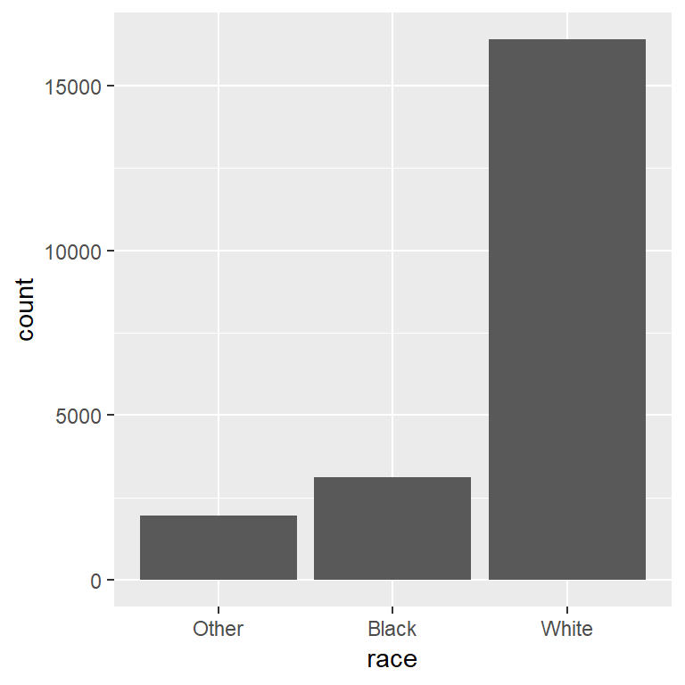

```r
ggplot(gss_cat, aes(race)) +
  geom_bar()
```

**Here you can not see “empty” levels**

## Unused levels

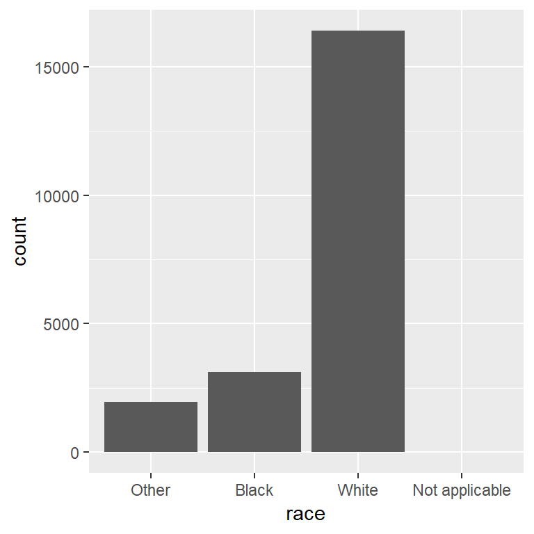

```r
ggplot(gss_cat, aes(race)) +
  geom_bar() +
  scale_x_discrete(drop = FALSE)
```

## Modifying factor order

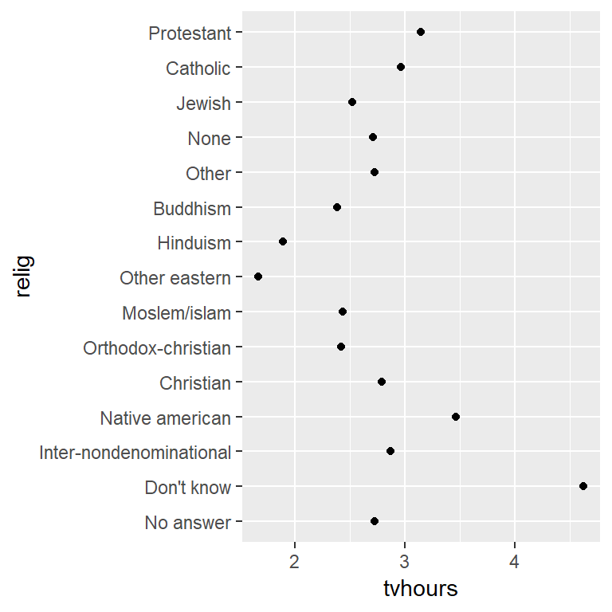

## Improving the factor ordering

We can improve it by reordering the levels of `relig` using `fct_reorder()`. `fct_reorder()` takes three arguments:

- `f`, the factor whose levels you want to modify.
- `x`, a numeric vector that you want to use to reorder the levels.
- Optionally, `fun`, a function that’s used if there are multiple values of `x` for each value of `f`. The default value is `median`.

## Reordered

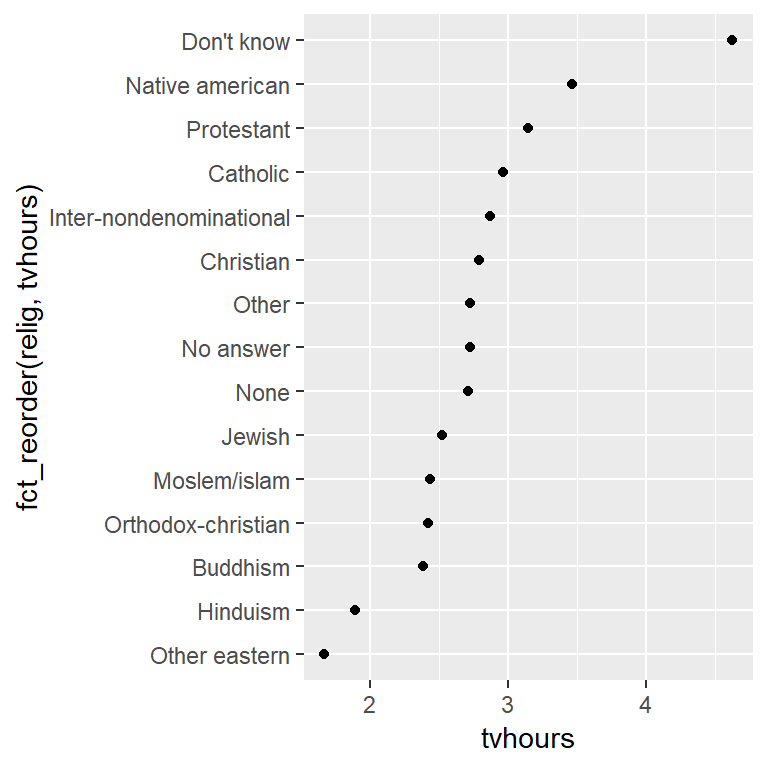

```r
ggplot(relig, aes(tvhours, fct_reorder(relig, tvhours))) +
  geom_point()
```

## Using “mutate()”

As you start making more complicated transformations, I’d recommend moving them out of `aes()` and into a separate `mutate()` step. For example, you could rewrite the plot above as:

```r
relig %>%
  mutate(relig = fct_reorder(relig, tvhours)) %>%
  ggplot(aes(tvhours, relig)) +
    geom_point()
```

## “fct_relevel” vs “fct_reorder”

What if we create a similar plot looking at how average age varies across reported income level?

[figure not shown]

```r
rincome <- gss_cat %>%
  group_by(rincome) %>%
  summarise(
    age = mean(age, na.rm = TRUE),
    tvhours = mean(tvhours, na.rm = TRUE),
    n = n())
ggplot(rincome, aes(age, fct_reorder(rincome, age))) + geom_point()
```

## Arbitrary order vs principle order

- Here, arbitrarily reordering the levels isn’t a good idea!
- That’s because `rincome` already has a principled order that we shouldn’t mess with.
- Reserve `fct_reorder()` for factors whose levels are arbitrarily ordered.

## Using “fct_relevel”

- It does make sense to pull “Not applicable” to the front with the other special levels.
- You can use `fct_relevel()`.
- It takes a factor, `f`, and then any number of levels that you want to move to the front of the line.

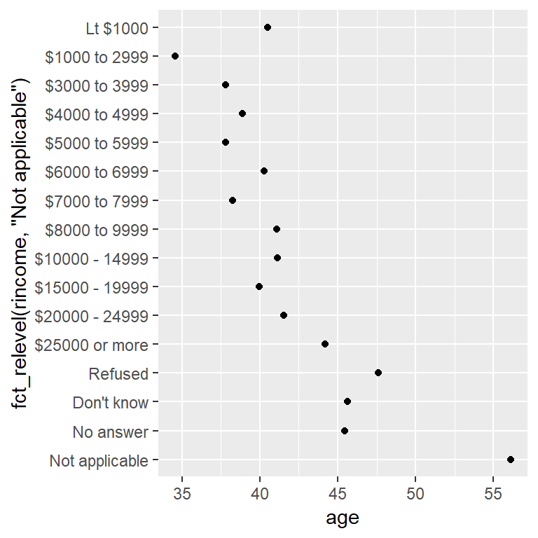

```r
ggplot(rincome, aes(age, fct_relevel(rincome, "Not applicable"))) +
  geom_point()
```

## Recode factors for line colours

[figure not shown]

[figure not shown]

## Order factors for bar plots

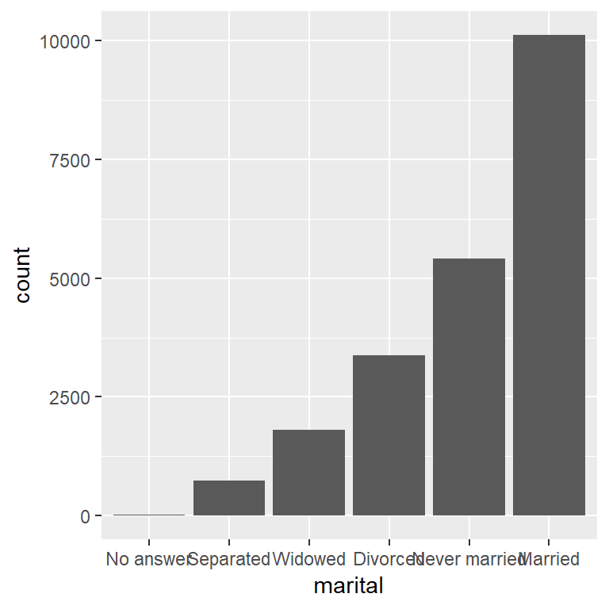

```r
gss_cat %>%
  mutate(marital = marital %>% fct_infreq() %>% fct_rev()) %>%
  ggplot(aes(marital)) +
    geom_bar()
```

## Modifying factor level values

- The most general and powerful tool is `fct_recode()`. * It allows you to recode, or change, the value of each level. For example, take the `gss_cat$partyid`:

```r
gss_cat %>% count(partyid)
```

```
## # A tibble: 10 x 2
##    partyid                n
##    <fct>              <int>
##  1 No answer            154
##  2 Don't know             1
##  3 Other party          393
##  4 Strong republican   2314
##  5 Not str republican  3032
##  6 Ind,near rep        1791
##  7 Independent         4119
##  8 Ind,near dem        2499
##  9 Not str democrat    3690
## 10 Strong democrat     3490
```

## Changing level labels, example

```r
gss_cat %>%
  mutate(partyid = fct_recode(partyid,
    "Republican, strong"    = "Strong republican",
    "Republican, weak"      = "Not str republican",
    "Independent, near rep" = "Ind,near rep",
    "Independent, near dem" = "Ind,near dem",
    "Democrat, weak"        = "Not str democrat",
    "Democrat, strong"      = "Strong democrat"
  )) %>%
  count(partyid)
```

```
## # A tibble: 10 x 2
##    partyid                   n
##    <fct>                 <int>
##  1 No answer               154
##  2 Don't know                1
##  3 Other party             393
##  4 Republican, strong     2314
##  5 Republican, weak       3032
##  6 Independent, near rep  1791
##  7 Independent            4119
##  8 Independent, near dem  2499
##  9 Democrat, weak         3690
## 10 Democrat, strong       3490
```

## Collapsing levels

```r
gss_cat %>%
  mutate(partyid = fct_recode(partyid,
    "Republican, strong"    = "Strong republican",
    "Republican, weak"      = "Not str republican",
    "Independent, near rep" = "Ind,near rep",
    "Independent, near dem" = "Ind,near dem",
    "Democrat, weak"        = "Not str democrat",
    "Democrat, strong"      = "Strong democrat",
    "Other"                 = "No answer",
    "Other"                 = "Don't know",
    "Other"                 = "Other party"
  )) %>%
  count(partyid)
```

```
## # A tibble: 8 x 2
##   partyid                   n
##   <fct>                 <int>
## 1 Other                   548
## 2 Republican, strong     2314
## 3 Republican, weak       3032
## 4 Independent, near rep  1791
## 5 Independent            4119
## 6 Independent, near dem  2499
## 7 Democrat, weak         3690
## 8 Democrat, strong       3490
```

## Collapse many levels

If you want to collapse a lot of levels, `fct_collapse()` is a useful variant of `fct_recode()`. For each new variable, you can provide a vector of old levels:

```r
gss_cat %>%
  mutate(partyid = fct_collapse(partyid,
    other = c("No answer", "Don't know", "Other party"),
    rep = c("Strong republican", "Not str republican"),
    ind = c("Ind,near rep", "Independent", "Ind,near dem"),
    dem = c("Not str democrat", "Strong democrat")
  )) %>%
  count(partyid)
```

```
## # A tibble: 4 x 2
##   partyid     n
##   <fct>   <int>
## 1 other     548
## 2 rep      5346
## 3 ind      8409
## 4 dem      7180
```

## Lump levels together

Sometimes you just want to lump together all the small groups to make a plot or table simpler. That’s the job of `fct_lump()`:

```r
gss_cat %>%
  mutate(relig = fct_lump(relig)) %>%
  count(relig)
```

```
## # A tibble: 2 x 2
##   relig          n
##   <fct>      <int>
## 1 Protestant 10846
## 2 Other      10637
```

## Specifying how many groups

Instead, we can use the `n` parameter to specify how many groups (excluding other) we want to keep:

```r
gss_cat %>%
  mutate(relig = fct_lump(relig, n = 10)) %>%
  count(relig, sort = TRUE) %>%
  print(n = Inf)
```

```
## # A tibble: 10 x 2
##    relig                       n
##    <fct>                   <int>
##  1 Protestant              10846
##  2 Catholic                 5124
##  3 None                     3523
##  4 Christian                 689
##  5 Other                     458
##  6 Jewish                    388
##  7 Buddhism                  147
##  8 Inter-nondenominational   109
##  9 Moslem/islam              104
## 10 Orthodox-christian         95
```